# Relatório 03 - Medidas de Posição e Dispersão

Luciano Vaz

16/09/2026

# Sumário

1. Introdução
2. Descrição do banco de dados

2.1 Importação e preparação dos dados

3. Visualização inicial dos dados

3.1 Estrutura do banco

3.2 Quantidade de observações

3.3 Valores ausentes

4. Medidas de posição

4.1 Média

4.2 Mediana

4.3 Moda

4.4 Quartis e percentis

5. Medidas de dispersão

5.1 Amplitude total

5.2 Amplitude interquartil

5.3 Variância

5.4 Desvio-padrão

5.5 Coeficiente de variação

6. Comparação entre grupos

6.1 Notas segundo o acesso à internet

6.2 Notas segundo a escolaridade da mãe

6.3 Faltas segundo o turno

7. Representações gráficas

7.1 Histograma das faltas

7.2 Histograma das notas

7.3 Boxplot das notas

7.4 Boxplot das faltas

7.5 Notas segundo o acesso à internet

7.6 Notas segundo a escolaridade da mãe

7.7 Notas segundo o turno

8. Discussão dos resultados

8.1 Média versus mediana

8.2 O efeito da variabilidade

8.3 Medidas adequadas para a análise

9. Tabela estatística-síntese
10. Síntese e reflexão

10.1 Qual medida de posição melhor representa as notas médias?

10.2 Qual medida representa o número de faltas?

10.3 Qual das duas variáveis apresenta maior variabilidade relativa?

10.4 A análise das medidas de dispersão é importante?

10.5 Quais grupos foram comparados?

10.6 Quais cuidados devem ser tomados?

10.7 Limitações da análise

11. Conclusões
12. Limitações da análise
13. Referências bibliográficas
14. Código R utilizado

# Introdução

Este relatório apresenta uma análise estatística de um conjunto de dados referente a alunos. O objetivo é utilizar medidas de posição, medidas de dispersão, tabelas e representações gráficas para descrever e comparar as principais características das variáveis analisadas.

As variáveis utilizadas são:

- **faltas**: número de faltas do aluno;
- **nota_media**: nota média do aluno;
- **turno**: turno em que o aluno estuda;
- **escolaridade_mae**: nível de escolaridade da mãe;
- **acesso_internet**: indicação de acesso à internet.

A análise busca compreender o comportamento das notas médias e do número de faltas, além de verificar diferenças entre grupos definidos pelo acesso à internet, escolaridade da mãe e turno de estudo.

# Descrição do banco de dados

## Importação e preparação dos dados

```r
pacotes <- c("ggplot2", "knitr")

instalados <- rownames(installed.packages())

for (p in pacotes) {
  if (!(p %in% instalados)) {
    install.packages(p, repos = "https://cloud.r-project.org")
  }
}

library(ggplot2)
library(knitr)

options(stringsAsFactors = FALSE)

arquivo_csv <- "dados_alunos.csv"

pasta_rmd <- tryCatch(
  dirname(knitr::current_input(dir = TRUE)),
  error = function(e) getwd()
)

arquivo_rmd <- file.path(pasta_rmd, arquivo_csv)

if (file.exists(arquivo_rmd)) {
  arquivo_csv <- arquivo_rmd
}

if (!file.exists(arquivo_csv)) {
  stop(
    paste0(
      "\nERRO: o arquivo 'dados_alunos.csv' não foi encontrado.\n\n",
      "Coloque o arquivo 'dados_alunos.csv' na mesma pasta do arquivo 'index.Rmd'.\n\n",
      "Pasta procurada: ",
      normalizePath(
        pasta_rmd,
        winslash = "/",
        mustWork = FALSE
      ),
      "\n"
    )
  )
}

dados_alunos <- tryCatch(
  read.csv2(
    arquivo_csv,
    header = TRUE,
    stringsAsFactors = FALSE,
    check.names = FALSE,
    na.strings = c("", "NA", "NaN")
  ),
  error = function(e) NULL
)

if (is.null(dados_alunos) || ncol(dados_alunos) == 1) {
  dados_alunos <- tryCatch(
    read.csv(
      arquivo_csv,
      header = TRUE,
      stringsAsFactors = FALSE,
      check.names = FALSE,
      na.strings = c("", "NA", "NaN")
    ),
    error = function(e) NULL
  )
}

if (is.null(dados_alunos)) {
  stop("Não foi possível importar o arquivo dados_alunos.csv.")
}

variaveis_necessarias <- c(
  "faltas",
  "nota_media",
  "turno",
  "escolaridade_mae",
  "acesso_internet"
)

variaveis_faltantes <- setdiff(
  variaveis_necessarias,
  names(dados_alunos)
)

if (length(variaveis_faltantes) > 0) {
  stop(
    paste0(
      "As seguintes variáveis não foram encontradas no arquivo: ",
      paste(variaveis_faltantes, collapse = ", "),
      "\n\nVariáveis encontradas: ",
      paste(names(dados_alunos), collapse = ", ")
    )
  )
}

dados_alunos$faltas <- as.numeric(
  gsub(
    ",",
    ".",
    as.character(dados_alunos$faltas),
    fixed = TRUE
  )
)

dados_alunos$nota_media <- as.numeric(
  gsub(
    ",",
    ".",
    as.character(dados_alunos$nota_media),
    fixed = TRUE
  )
)

dados_alunos$turno <- factor(
  as.character(dados_alunos$turno),
  levels = c(
    "Matutino",
    "Vespertino",
    "Noturno"
  )
)

dados_alunos$escolaridade_mae <- factor(
  as.character(dados_alunos$escolaridade_mae),
  levels = c(
    "Fundamental",
    "Médio",
    "Superior"
  )
)

dados_alunos$acesso_internet <- factor(
  as.character(dados_alunos$acesso_internet),
  levels = c(
    "Não",
    "Sim"
  )
)

moda <- function(x) {
  x <- x[!is.na(x)]

  if (length(x) == 0) {
    return(NA)
  }

  tabela <- table(x)

  nomes <- names(
    tabela[tabela == max(tabela)]
  )

  paste(nomes, collapse = ", ")
}
```

# 3. Visualização inicial dos dados

## 3.1 Estrutura do banco

```r
str(dados_alunos)
```

```
## 'data.frame':    1000 obs. of  5 variables:
##  $ faltas          : num  11 8 9 7 7 16 12 7 8 7 ...
##  $ nota_media      : num  10 8.3 9.2 5.8 8.6 5.3 7.8 6.7 5.5 7.3 ...
##  $ turno           : Factor w/ 3 levels "Matutino","Vespertino",..: 2 1 2 1 2 2 1 2 1 3 ...
##  $ escolaridade_mae: Factor w/ 3 levels "Fundamental",..: 2 1 1 2 1 2 1 1 2 2 ...
##  $ acesso_internet : Factor w/ 2 levels "Não","Sim": 2 2 2 2 1 2 2 1 2 2 ...
```

O banco de dados possui informações referentes às características acadêmicas e sociais dos alunos. As variáveis numéricas principais utilizadas na análise são o número de faltas e a nota média.

## 3.2 Quantidade de observações

```r
n_observacoes <- nrow(dados_alunos)
n_variaveis <- ncol(dados_alunos)

tabela_dimensao <- data.frame(
  Informação = c(
    "Número de observações",
    "Número de variáveis"
  ),
  Valor = c(
    n_observacoes,
    n_variaveis
  )
)

kable(
  tabela_dimensao,
  caption = "Dimensão do banco de dados"
)
```

Dimensão do banco de dados

| Informação | Valor |
| --- | --- |
| Número de observações | 1000 |
| Número de variáveis | 5 |

## Valores ausentes

```r
valores_ausentes <- colSums(is.na(dados_alunos))

tabela_ausentes <- data.frame(
  Variável = names(valores_ausentes),
  Valores_Ausentes = as.numeric(valores_ausentes)
)

kable(
  tabela_ausentes,
  caption = "Quantidade de valores ausentes por variável"
)
```

Quantidade de valores ausentes por variável

| Variável | Valores_Ausentes |
| --- | --- |
| faltas | 0 |
| nota_media | 0 |
| turno | 0 |
| escolaridade_mae | 0 |
| acesso_internet | 0 |

# Medidas de posição

As medidas de posição permitem identificar valores que representam o centro ou a localização dos dados. Nesta análise são consideradas a média, a mediana e a moda.

## Média

```r
media_faltas <- mean(
  dados_alunos$faltas,
  na.rm = TRUE
)

media_notas <- mean(
  dados_alunos$nota_media,
  na.rm = TRUE
)

tabela_media <- data.frame(
  Variável = c(
    "Faltas",
    "Nota média"
  ),
  Média = c(
    media_faltas,
    media_notas
  )
)

kable(
  tabela_media,
  digits = 2,
  caption = "Médias das variáveis numéricas"
)
```

Médias das variáveis numéricas

| Variável | Média |
| --- | --- |
| Faltas | 8.01 |
| Nota média | 6.44 |

A média representa o valor obtido pela soma das observações dividida pelo número de observações válidas.

## Mediana

```r
mediana_faltas <- median(
  dados_alunos$faltas,
  na.rm = TRUE
)

mediana_notas <- median(
  dados_alunos$nota_media,
  na.rm = TRUE
)

tabela_mediana <- data.frame(
  Variável = c(
    "Faltas",
    "Nota média"
  ),
  Mediana = c(
    mediana_faltas,
    mediana_notas
  )
)

kable(
  tabela_mediana,
  digits = 2,
  caption = "Medianas das variáveis numéricas"
)
```

Medianas das variáveis numéricas

| Variável | Mediana |
| --- | --- |
| Faltas | 8.0 |
| Nota média | 6.5 |

A mediana corresponde ao valor que divide os dados ordenados em duas partes de mesmo tamanho.

## Moda

```r
moda_faltas <- moda(dados_alunos$faltas)
moda_notas <- moda(dados_alunos$nota_media)

tabela_moda <- data.frame(
  Variável = c(
    "Faltas",
    "Nota média"
  ),
  Moda = c(
    moda_faltas,
    moda_notas
  )
)

kable(
  tabela_moda,
  caption = "Modas das variáveis numéricas"
)
```

Modas das variáveis numéricas

| Variável | Moda |
| --- | --- |
| Faltas | 7 |
| Nota média | 10 |

A moda é o valor que apresenta maior frequência na distribuição.

## Quartis e percentis

```r
quartis_faltas <- quantile(
  dados_alunos$faltas,
  probs = c(0, 0.25, 0.50, 0.75, 1),
  na.rm = TRUE
)

quartis_notas <- quantile(
  dados_alunos$nota_media,
  probs = c(0, 0.25, 0.50, 0.75, 1),
  na.rm = TRUE
)

tabela_quartis <- data.frame(
  Medida = c(
    "Mínimo",
    "1º Quartil",
    "Mediana",
    "3º Quartil",
    "Máximo"
  ),
  Faltas = as.numeric(quartis_faltas),
  Nota_Média = as.numeric(quartis_notas)
)

kable(
  tabela_quartis,
  digits = 2,
  caption = "Quartis e extremos das variáveis"
)
```

Quartis e extremos das variáveis

| Medida | Faltas | Nota_Média |
| --- | --- | --- |
| Mínimo | 1 | 0.5 |
| 1º Quartil | 6 | 5.2 |
| Mediana | 8 | 6.5 |
| 3º Quartil | 10 | 7.7 |
| Máximo | 19 | 10.0 |

Os quartis permitem observar a distribuição dos dados em quatro partes. O primeiro quartil corresponde a 25% das observações, enquanto o terceiro quartil corresponde a 75%.

# Medidas de dispersão

As medidas de dispersão permitem avaliar o quanto os dados se afastam de seus valores centrais.

## Amplitude total

```r
amplitude_faltas <- max(
  dados_alunos$faltas,
  na.rm = TRUE
) - min(
  dados_alunos$faltas,
  na.rm = TRUE
)

amplitude_notas <- max(
  dados_alunos$nota_media,
  na.rm = TRUE
) - min(
  dados_alunos$nota_media,
  na.rm = TRUE
)

tabela_amplitude <- data.frame(
  Variável = c(
    "Faltas",
    "Nota média"
  ),
  Amplitude_Total = c(
    amplitude_faltas,
    amplitude_notas
  )
)

kable(
  tabela_amplitude,
  digits = 2,
  caption = "Amplitude total"
)
```

Amplitude total

| Variável | Amplitude_Total |
| --- | --- |
| Faltas | 18.0 |
| Nota média | 9.5 |

## Amplitude interquartil

```r
iqr_faltas <- IQR(
  dados_alunos$faltas,
  na.rm = TRUE
)

iqr_notas <- IQR(
  dados_alunos$nota_media,
  na.rm = TRUE
)

tabela_iqr <- data.frame(
  Variável = c(
    "Faltas",
    "Nota média"
  ),
  Amplitude_Interquartil = c(
    iqr_faltas,
    iqr_notas
  )
)

kable(
  tabela_iqr,
  digits = 2,
  caption = "Amplitude interquartil"
)
```

Amplitude interquartil

| Variável | Amplitude_Interquartil |
| --- | --- |
| Faltas | 4.0 |
| Nota média | 2.5 |

A amplitude interquartil corresponde à diferença entre o terceiro e o primeiro quartil.

## Variância

```r
variancia_faltas <- var(
  dados_alunos$faltas,
  na.rm = TRUE
)

variancia_notas <- var(
  dados_alunos$nota_media,
  na.rm = TRUE
)

tabela_variancia <- data.frame(
  Variável = c(
    "Faltas",
    "Nota média"
  ),
  Variância = c(
    variancia_faltas,
    variancia_notas
  )
)

kable(
  tabela_variancia,
  digits = 2,
  caption = "Variância"
)
```

Variância

| Variável | Variância |
| --- | --- |
| Faltas | 7.83 |
| Nota média | 3.54 |

## Desvio-padrão

```r
desvio_faltas <- sd(
  dados_alunos$faltas,
  na.rm = TRUE
)

desvio_notas <- sd(
  dados_alunos$nota_media,
  na.rm = TRUE
)

tabela_desvio <- data.frame(
  Variável = c(
    "Faltas",
    "Nota média"
  ),
  Desvio_Padrão = c(
    desvio_faltas,
    desvio_notas
  )
)

kable(
  tabela_desvio,
  digits = 2,
  caption = "Desvio-padrão"
)
```

Desvio-padrão

| Variável | Desvio_Padrão |
| --- | --- |
| Faltas | 2.80 |
| Nota média | 1.88 |

O desvio-padrão representa uma medida de dispersão em torno da média.

## Coeficiente de variação

```r
cv_faltas <- (
  desvio_faltas /
    media_faltas
) * 100

cv_notas <- (
  desvio_notas /
    media_notas
) * 100

tabela_cv <- data.frame(
  Variável = c(
    "Faltas",
    "Nota média"
  ),
  Coeficiente_de_Variação = c(
    cv_faltas,
    cv_notas
  )
)

kable(
  tabela_cv,
  digits = 2,
  caption = "Coeficiente de variação (%)"
)
```

Coeficiente de variação (%)

| Variável | Coeficiente_de_Variação |
| --- | --- |
| Faltas | 34.93 |
| Nota média | 29.21 |

O coeficiente de variação relaciona o desvio-padrão à média e é útil para comparar a variabilidade relativa de variáveis que possuem escalas diferentes.

# Comparação entre grupos

## Notas segundo o acesso à internet

```r
internet_nao <- dados_alunos$nota_media[
  dados_alunos$acesso_internet == "Não"
]

internet_nao <- internet_nao[
  !is.na(internet_nao)
]

internet_sim <- dados_alunos$nota_media[
  dados_alunos$acesso_internet == "Sim"
]

internet_sim <- internet_sim[
  !is.na(internet_sim)
]

tabela_internet <- data.frame(
  Acesso_Internet = c(
    "Não",
    "Sim"
  ),
  N = c(
    length(internet_nao),
    length(internet_sim)
  ),
  Média = c(
    ifelse(
      length(internet_nao) > 0,
      mean(internet_nao),
      NA
    ),
    ifelse(
      length(internet_sim) > 0,
      mean(internet_sim),
      NA
    )
  ),
  Mediana = c(
    ifelse(
      length(internet_nao) > 0,
      median(internet_nao),
      NA
    ),
    ifelse(
      length(internet_sim) > 0,
      median(internet_sim),
      NA
    )
  ),
  Desvio_Padrão = c(
    ifelse(
      length(internet_nao) > 1,
      sd(internet_nao),
      NA
    ),
    ifelse(
      length(internet_sim) > 1,
      sd(internet_sim),
      NA
    )
  ),
  Mínimo = c(
    ifelse(
      length(internet_nao) > 0,
      min(internet_nao),
      NA
    ),
    ifelse(
      length(internet_sim) > 0,
      min(internet_sim),
      NA
    )
  ),
  Máximo = c(
    ifelse(
      length(internet_nao) > 0,
      max(internet_nao),
      NA
    ),
    ifelse(
      length(internet_sim) > 0,
      max(internet_sim),
      NA
    )
  )
)

kable(
  tabela_internet,
  digits = 2,
  caption = "Notas segundo o acesso à internet"
)
```

Notas segundo o acesso à internet

| Acesso_Internet | N | Média | Mediana | Desvio_Padrão | Mínimo | Máximo |
| --- | --- | --- | --- | --- | --- | --- |
| Não | 297 | 6.48 | 6.5 | 1.90 | 1.1 | 10 |
| Sim | 703 | 6.43 | 6.5 | 1.87 | 0.5 | 10 |

A comparação permite observar diferenças nas medidas de posição e dispersão das notas entre alunos com e sem acesso à internet.

## Notas segundo a escolaridade da mãe

```r
notas_fundamental <- dados_alunos$nota_media[
  dados_alunos$escolaridade_mae == "Fundamental"
]

notas_fundamental <- notas_fundamental[
  !is.na(notas_fundamental)
]

notas_medio <- dados_alunos$nota_media[
  dados_alunos$escolaridade_mae == "Médio"
]

notas_medio <- notas_medio[
  !is.na(notas_medio)
]

notas_superior <- dados_alunos$nota_media[
  dados_alunos$escolaridade_mae == "Superior"
]

notas_superior <- notas_superior[
  !is.na(notas_superior)
]

tabela_escolaridade <- data.frame(
  Escolaridade_Mae = c(
    "Fundamental",
    "Médio",
    "Superior"
  ),
  N = c(
    length(notas_fundamental),
    length(notas_medio),
    length(notas_superior)
  ),
  Média = c(
    ifelse(
      length(notas_fundamental) > 0,
      mean(notas_fundamental),
      NA
    ),
    ifelse(
      length(notas_medio) > 0,
      mean(notas_medio),
      NA
    ),
    ifelse(
      length(notas_superior) > 0,
      mean(notas_superior),
      NA
    )
  ),
  Mediana = c(
    ifelse(
      length(notas_fundamental) > 0,
      median(notas_fundamental),
      NA
    ),
    ifelse(
      length(notas_medio) > 0,
      median(notas_medio),
      NA
    ),
    ifelse(
      length(notas_superior) > 0,
      median(notas_superior),
      NA
    )
  ),
  Desvio_Padrão = c(
    ifelse(
      length(notas_fundamental) > 1,
      sd(notas_fundamental),
      NA
    ),
    ifelse(
      length(notas_medio) > 1,
      sd(notas_medio),
      NA
    ),
    ifelse(
      length(notas_superior) > 1,
      sd(notas_superior),
      NA
    )
  )
)

kable(
  tabela_escolaridade,
  digits = 2,
  caption = "Notas segundo a escolaridade da mãe"
)
```

Notas segundo a escolaridade da mãe

| Escolaridade_Mae | N | Média | Mediana | Desvio_Padrão |
| --- | --- | --- | --- | --- |
| Fundamental | 391 | 6.33 | 6.5 | 1.85 |
| Médio | 459 | 6.55 | 6.5 | 1.85 |
| Superior | 150 | 6.41 | 6.2 | 2.05 |

A tabela apresenta as medidas principais das notas para os diferentes níveis de escolaridade materna.

## Faltas segundo o turno

```r
faltas_matutino <- dados_alunos$faltas[
  dados_alunos$turno == "Matutino"
]

faltas_matutino <- faltas_matutino[
  !is.na(faltas_matutino)
]

faltas_vespertino <- dados_alunos$faltas[
  dados_alunos$turno == "Vespertino"
]

faltas_vespertino <- faltas_vespertino[
  !is.na(faltas_vespertino)
]

faltas_noturno <- dados_alunos$faltas[
  dados_alunos$turno == "Noturno"
]

faltas_noturno <- faltas_noturno[
  !is.na(faltas_noturno)
]

tabela_turno <- data.frame(
  Turno = c(
    "Matutino",
    "Vespertino",
    "Noturno"
  ),
  N = c(
    length(faltas_matutino),
    length(faltas_vespertino),
    length(faltas_noturno)
  ),
  Média = c(
    ifelse(
      length(faltas_matutino) > 0,
      mean(faltas_matutino),
      NA
    ),
    ifelse(
      length(faltas_vespertino) > 0,
      mean(faltas_vespertino),
      NA
    ),
    ifelse(
      length(faltas_noturno) > 0,
      mean(faltas_noturno),
      NA
    )
  ),
  Mediana = c(
    ifelse(
      length(faltas_matutino) > 0,
      median(faltas_matutino),
      NA
    ),
    ifelse(
      length(faltas_vespertino) > 0,
      median(faltas_vespertino),
      NA
    ),
    ifelse(
      length(faltas_noturno) > 0,
      median(faltas_noturno),
      NA
    )
  ),
  Desvio_Padrão = c(
    ifelse(
      length(faltas_matutino) > 1,
      sd(faltas_matutino),
      NA
    ),
    ifelse(
      length(faltas_vespertino) > 1,
      sd(faltas_vespertino),
      NA
    ),
    ifelse(
      length(faltas_noturno) > 1,
      sd(faltas_noturno),
      NA
    )
  )
)

kable(
  tabela_turno,
  digits = 2,
  caption = "Faltas segundo o turno"
)
```

Faltas segundo o turno

| Turno | N | Média | Mediana | Desvio_Padrão |
| --- | --- | --- | --- | --- |
| Matutino | 451 | 8.03 | 8 | 2.78 |
| Vespertino | 345 | 8.03 | 8 | 2.91 |
| Noturno | 204 | 7.95 | 8 | 2.65 |

# Representações gráficas

## Histograma das faltas

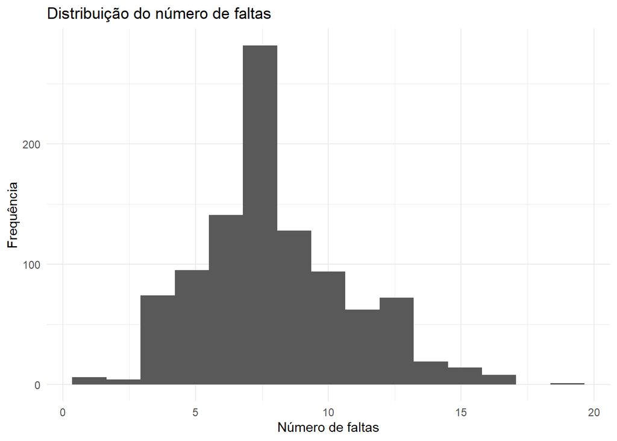

```r
ggplot(
  dados_alunos,
  aes(x = faltas)
) +
  geom_histogram(
    bins = 15,
    na.rm = TRUE
  ) +
  labs(
    title = "Distribuição do número de faltas",
    x = "Número de faltas",
    y = "Frequência"
  ) +
  theme_minimal()
```

O histograma permite visualizar a forma da distribuição do número de faltas.

## Histograma das notas

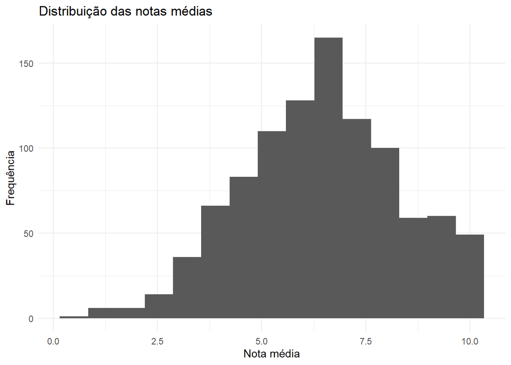

```r
ggplot(
  dados_alunos,
  aes(x = nota_media)
) +
  geom_histogram(
    bins = 15,
    na.rm = TRUE
  ) +
  labs(
    title = "Distribuição das notas médias",
    x = "Nota média",
    y = "Frequência"
  ) +
  theme_minimal()
```

O histograma das notas permite observar a concentração dos alunos em diferentes faixas de desempenho.

## Boxplot das notas

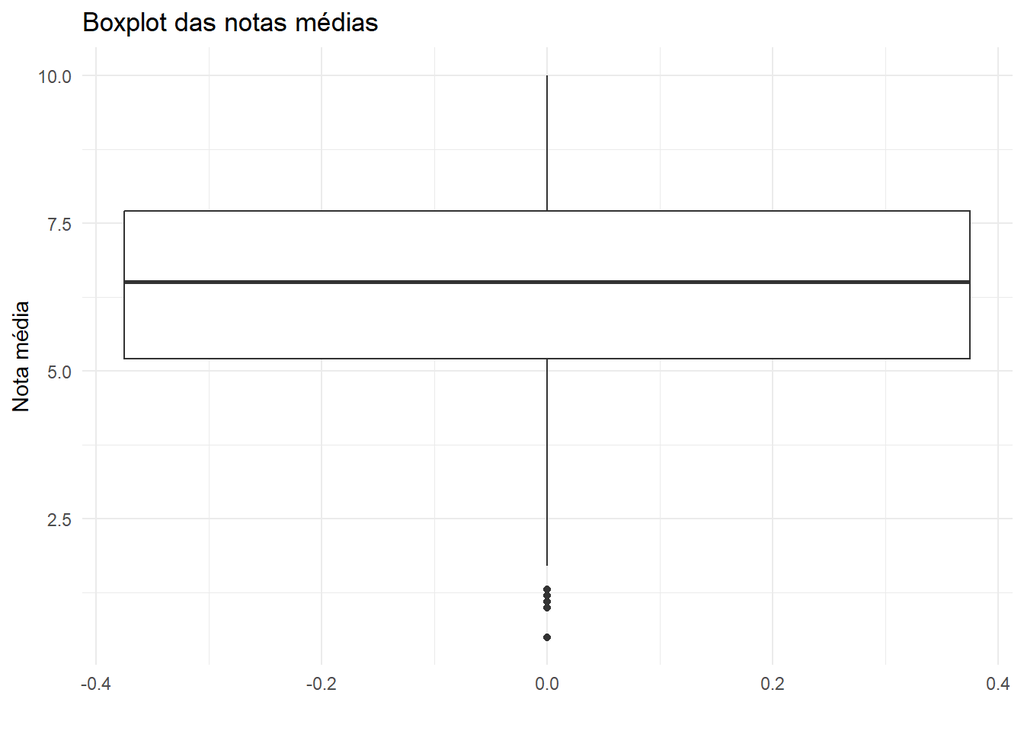

```r
ggplot(
  dados_alunos,
  aes(y = nota_media)
) +
  geom_boxplot(
    na.rm = TRUE
  ) +
  labs(
    title = "Boxplot das notas médias",
    y = "Nota média",
    x = ""
  ) +
  theme_minimal()
```

## Boxplot das faltas

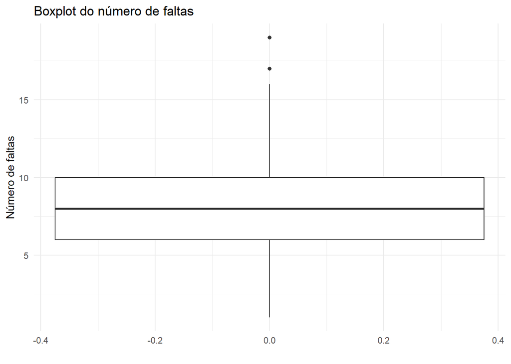

```r
ggplot(
  dados_alunos,
  aes(y = faltas)
) +
  geom_boxplot(
    na.rm = TRUE
  ) +
  labs(
    title = "Boxplot do número de faltas",
    y = "Número de faltas",
    x = ""
  ) +
  theme_minimal()
```

## Notas segundo o acesso à internet

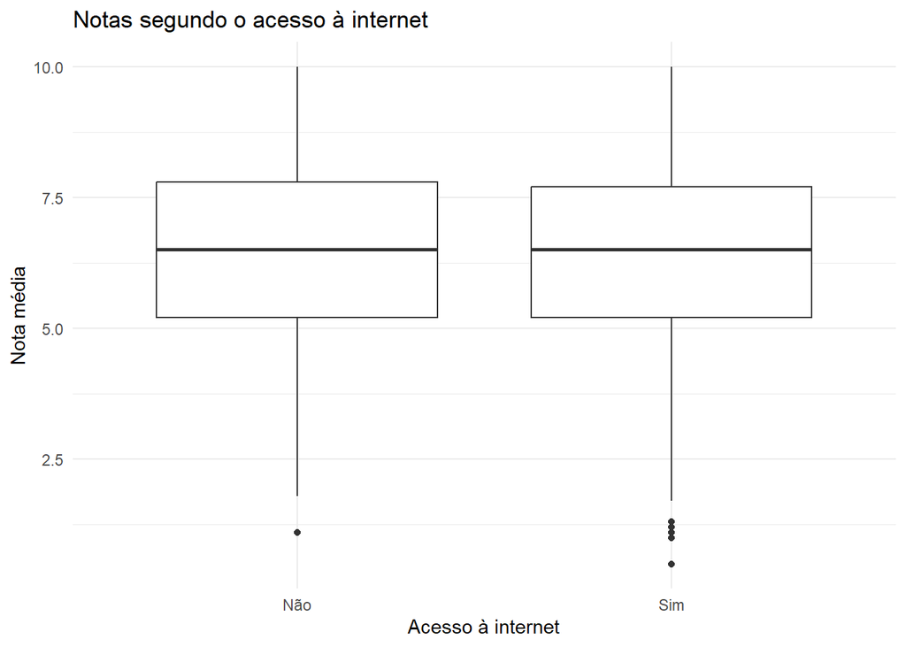

```r
ggplot(
  dados_alunos,
  aes(
    x = acesso_internet,
    y = nota_media
  )
) +
  geom_boxplot(
    na.rm = TRUE
  ) +
  labs(
    title = "Notas segundo o acesso à internet",
    x = "Acesso à internet",
    y = "Nota média"
  ) +
  theme_minimal()
```

## Notas segundo a escolaridade da mãe

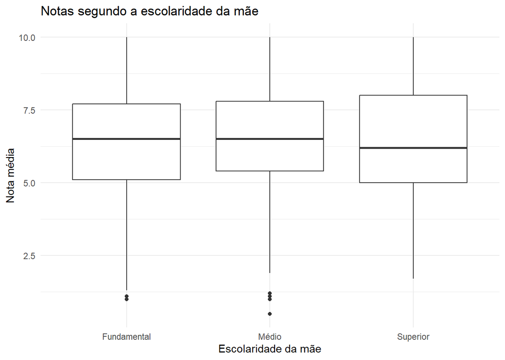

```r
ggplot(
  dados_alunos,
  aes(
    x = escolaridade_mae,
    y = nota_media
  )
) +
  geom_boxplot(
    na.rm = TRUE
  ) +
  labs(
    title = "Notas segundo a escolaridade da mãe",
    x = "Escolaridade da mãe",
    y = "Nota média"
  ) +
  theme_minimal()
```

## Notas segundo o turno

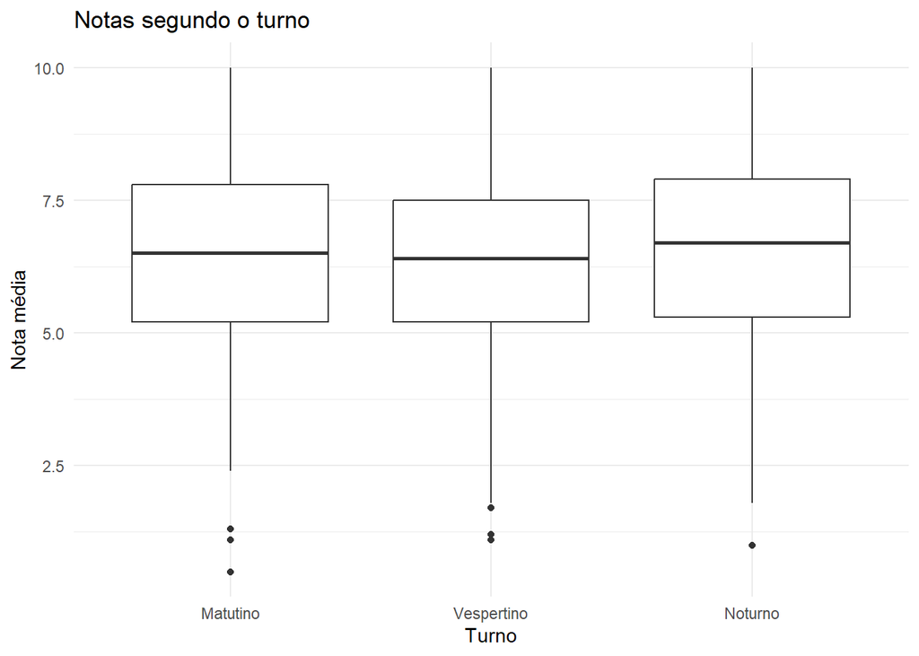

```r
ggplot(
  dados_alunos,
  aes(
    x = turno,
    y = nota_media
  )
) +
  geom_boxplot(
    na.rm = TRUE
  ) +
  labs(
    title = "Notas segundo o turno",
    x = "Turno",
    y = "Nota média"
  ) +
  theme_minimal()
```

# Discussão dos resultados

## Média versus mediana

A média das notas médias dos alunos é aproximadamente **6.44**, enquanto a mediana é **6.5**.

Para o número de faltas, a média é aproximadamente **8.01**, enquanto a mediana é **8**.

A comparação entre média e mediana auxilia na identificação de possíveis assimetrias na distribuição dos dados.

## O efeito da variabilidade

O desvio-padrão das notas é aproximadamente **1.88**, enquanto o desvio-padrão do número de faltas é aproximadamente **2.8**.

O coeficiente de variação permite analisar a variabilidade em termos relativos:

- notas médias: **29.21%**;
- faltas: **34.93%**.

Essa comparação deve considerar a natureza e a escala de cada variável.

## Medidas adequadas para a análise

Para as notas, média e mediana são medidas importantes de posição, enquanto desvio-padrão, amplitude interquartil e coeficiente de variação ajudam a compreender a dispersão.

Para o número de faltas, essas mesmas medidas podem ser utilizadas, sendo especialmente útil observar a mediana e os quartis quando existem valores extremos.

# Tabela estatística-síntese

```r
tabela_sintese <- data.frame(
  Medida = c(
    "Média",
    "Mediana",
    "Mínimo",
    "1º Quartil",
    "3º Quartil",
    "Máximo",
    "Amplitude",
    "Amplitude Interquartil",
    "Variância",
    "Desvio-padrão",
    "Coeficiente de variação (%)"
  ),
  Faltas = c(
    media_faltas,
    mediana_faltas,
    min(dados_alunos$faltas, na.rm = TRUE),
    quantile(dados_alunos$faltas, 0.25, na.rm = TRUE),
    quantile(dados_alunos$faltas, 0.75, na.rm = TRUE),
    max(dados_alunos$faltas, na.rm = TRUE),
    amplitude_faltas,
    iqr_faltas,
    variancia_faltas,
    desvio_faltas,
    cv_faltas
  ),
  Nota_Média = c(
    media_notas,
    mediana_notas,
    min(dados_alunos$nota_media, na.rm = TRUE),
    quantile(dados_alunos$nota_media, 0.25, na.rm = TRUE),
    quantile(dados_alunos$nota_media, 0.75, na.rm = TRUE),
    max(dados_alunos$nota_media, na.rm = TRUE),
    amplitude_notas,
    iqr_notas,
    variancia_notas,
    desvio_notas,
    cv_notas
  )
)

kable(
  tabela_sintese,
  digits = 2,
  caption = "Síntese das principais medidas estatísticas"
)
```

Síntese das principais medidas estatísticas

| Medida | Faltas | Nota_Média |
| --- | --- | --- |
| Média | 8.01 | 6.44 |
| Mediana | 8.00 | 6.50 |
| Mínimo | 1.00 | 0.50 |
| 1º Quartil | 6.00 | 5.20 |
| 3º Quartil | 10.00 | 7.70 |
| Máximo | 19.00 | 10.00 |
| Amplitude | 18.00 | 9.50 |
| Amplitude Interquartil | 4.00 | 2.50 |
| Variância | 7.83 | 3.54 |
| Desvio-padrão | 2.80 | 1.88 |
| Coeficiente de variação (%) | 34.93 | 29.21 |

# Síntese e reflexão

## Qual medida de posição melhor representa as notas médias?

A escolha entre média e mediana depende do formato da distribuição das notas. Quando os dados não apresentam forte assimetria ou valores extremos, a média pode representar adequadamente o conjunto. A mediana pode ser mais informativa quando existem valores extremos ou assimetria.

## Qual medida representa o número de faltas?

A média fornece o número médio de faltas dos alunos. A mediana, por sua vez, representa o ponto central da distribuição e pode ser útil quando há diferenças importantes entre alunos ou valores extremos.

## Qual das duas variáveis apresenta maior variabilidade relativa?

A comparação deve ser feita utilizando o coeficiente de variação:

- Faltas: **34.93%**
- Nota média: **29.21%**

O maior coeficiente indica maior variabilidade relativa em relação à própria média.

## A análise das medidas de dispersão é importante?

Sim. As medidas de dispersão complementam as medidas de posição. Duas distribuições podem apresentar médias semelhantes, mas possuir diferentes níveis de variabilidade.

## Quais grupos foram comparados?

Foram comparados:

1. alunos com e sem acesso à internet;
2. alunos segundo o nível de escolaridade da mãe;
3. alunos segundo o turno de estudo.

Essas comparações permitem observar como as medidas estatísticas se comportam entre diferentes grupos do banco de dados.

## Quais cuidados devem ser tomados?

Os resultados devem ser interpretados considerando o tamanho da amostra, a presença de valores ausentes, possíveis valores extremos e as características das variáveis.

Diferenças descritivas entre grupos não devem ser interpretadas automaticamente como relações de causa e efeito.

## Limitações da análise

A análise é baseada nas informações disponíveis no banco de dados. Portanto, as conclusões estão limitadas às variáveis observadas e à qualidade dos dados fornecidos.

# Conclusões

A análise estatística permitiu descrever o comportamento das notas médias e do número de faltas dos alunos por meio de medidas de posição e dispersão.

Foram calculadas média, mediana, moda, quartis, amplitude, amplitude interquartil, variância, desvio-padrão e coeficiente de variação.

Também foram realizadas comparações entre grupos segundo acesso à internet, escolaridade da mãe e turno de estudo.

As representações gráficas complementaram as tabelas estatísticas, permitindo observar visualmente a distribuição das variáveis e as diferenças existentes entre os grupos.

De maneira geral, a combinação entre medidas de posição, medidas de dispersão e gráficos proporciona uma visão mais completa dos dados do que a utilização de uma única medida estatística.

# Limitações da análise

Os resultados apresentados são descritivos e dependem das informações existentes no arquivo `dados_alunos.csv`.

Não é possível estabelecer relações causais apenas com as comparações apresentadas. Diferenças observadas entre grupos devem ser interpretadas com cautela e considerando possíveis fatores adicionais que não estejam presentes no banco de dados.

# Referências bibliográficas

R CORE TEAM. *R: A Language and Environment for Statistical Computing*. Vienna: R Foundation for Statistical Computing.

TRIOLA, M. F. *Introdução à Estatística*. Rio de Janeiro: LTC.

BUSSAB, W. O.; MORETTIN, P. A. *Estatística Básica*. São Paulo: Saraiva.

# Código R utilizado

O presente relatório foi desenvolvido utilizando a linguagem R e o R Markdown. Foram utilizados principalmente os pacotes `ggplot2` para elaboração dos gráficos e `knitr` para apresentação das tabelas.